# Repaso de regresiones

Curso: POL304 - Estadística para el análisis político 2

Alexander Benites, Chiara Zamora y Airam Bello

Ciclo 2023-2

### A. Regresión Lineal (OLS)

El modelo de regresión básico. Evalúa el impacto de una (o varias) variables independientes (o predictores) sobre una variable dependiente que debe ser numérica continua.

Vamos a traer una base de datos con los resultados de las ERM del año 2018, solo para los distritos de la provincia de Lima. Los datos ya se encuentran limpios.

```r
library(rio)
dataols = import("https://github.com/Alexanderbenit7/ERM2018/raw/master/finalData.csv")
dataols = dataols[,c(15,1,3,6,9,4,7)]
```

Vamos a cambiar algunos nombres y a sacar la tasa de personas con discapacidad en el distrito:

```r
colnames(dataols) = c("Vote","Dist","Ubigeo","Disc","Pobre","Pop","IVA")
dataols$Dic_porc = dataols$Disc/dataols$Pop
dataols$IVA_cat = factor(ifelse(dataols$IVA>0.173227,1,0))
```

Estas son las variables:

- Vote: Porcentaje de votos por AP
- Dist: Nombre del distrito
- Disc: Número de personas con alguna discapacidad en el disrito
- Pobre: Porcentaje de personas en situación de pobreza monetaria en el distrito
- IVA: índice de vulnerabilidad alimentaria
- IVA_cat: Distrito por encima de la media del IVA

Queremos conocer las variables que explicarían el voto por Acción Popular en los distritos de Lima en esa elección. Imaginen que les piden comprobar esta hipótesis:

Voto por AP = El porcentaje de personas con discapacidad + El % de personas en situación de pobreza.

```r
reg_ols = lm(Vote ~ Dic_porc + Pobre, data = dataols)
summary(reg_ols)
```

```
##
## Call:
## lm(formula = Vote ~ Dic_porc + Pobre, data = dataols)
##
## Residuals:
##      Min       1Q   Median       3Q      Max
## -27.4040  -2.1278   0.3764   3.3120  17.6711
##
## Coefficients:
##              Estimate Std. Error t value Pr(>|t|)
## (Intercept)   62.1219     5.1281  12.114 5.81e-15 ***
## Dic_porc    -682.9640   588.4504  -1.161    0.253
## Pobre         -1.7541     0.1388 -12.640 1.49e-15 ***
## ---
## Signif. codes:  0 '***' 0.001 '**' 0.01 '*' 0.05 '.' 0.1 ' ' 1
##
## Residual standard error: 6.91 on 40 degrees of freedom
## Multiple R-squared:    0.8,  Adjusted R-squared:   0.79
## F-statistic: 80.01 on 2 and 40 DF,  p-value: 1.047e-14
```

Ahora le piden tomar en consideración si el distrito está por encima del promedio del IVA

```r
reg_ols1 = lm(Vote ~ Dic_porc + Pobre + IVA_cat, data = dataols)
summary(reg_ols1)
```

```
##
## Call:
## lm(formula = Vote ~ Dic_porc + Pobre + IVA_cat, data = dataols)
##
## Residuals:
##      Min       1Q   Median       3Q      Max
## -26.1826  -2.4920   0.1004   3.6361  18.0212
##
## Coefficients:
##              Estimate Std. Error t value Pr(>|t|)
## (Intercept)   62.5562     5.2361  11.947 1.32e-14 ***
## Dic_porc    -745.3106   604.8193  -1.232    0.225
## Pobre         -1.6860     0.1883  -8.955 5.30e-11 ***
## IVA_cat1      -1.5986     2.9566  -0.541    0.592
## ---
## Signif. codes:  0 '***' 0.001 '**' 0.01 '*' 0.05 '.' 0.1 ' ' 1
##
## Residual standard error: 6.972 on 39 degrees of freedom
## Multiple R-squared:  0.8015, Adjusted R-squared:  0.7862
## F-statistic: 52.49 on 3 and 39 DF,  p-value: 9.257e-14
```

Vemos que el predictor no es estadísticamente significativo, y parece que no nos cambia mucho el escenario. Podemos comprobarlo:

```r
library(magrittr)
library(knitr)
tanova=anova(reg_ols,reg_ols1)

kable(tanova,
      caption = "Tabla ANOVA para comparar modelos")%>%kableExtra::kable_styling(full_width = FALSE)
```

Tabla ANOVA para comparar modelos

| Res.Df | RSS | Df | Sum of Sq | F | Pr(>F) |
| --- | --- | --- | --- | --- | --- |
| 40 | 1910.157 | NA | NA | NA | NA |
| 39 | 1895.945 | 1 | 14.21219 | 0.2923478 | 0.5917949 |

Vemos que el p-valor no es estadísticamente significativo, por lo que no hay una mejora incluyendo la variable IVA_cat, que en parte ya sabíamos debido a que no es un predictor estadísticamente significativo.

Y si IVA_cat hubiera sigo estadísticamente significativo, y nos preguntaran por el predictor que tiene un impacto *mayor*?

```r
reg_ols1_st = lm(scale(Vote) ~ scale(Dic_porc) + scale(Pobre) + scale(as.numeric(IVA_cat)), data = dataols)
summary(reg_ols1_st)
```

```
##
## Call:
## lm(formula = scale(Vote) ~ scale(Dic_porc) + scale(Pobre) + scale(as.numeric(IVA_cat)),
##     data = dataols)
##
## Residuals:
##      Min       1Q   Median       3Q      Max
## -1.73621 -0.16525  0.00666  0.24111  1.19502
##
## Coefficients:
##                              Estimate Std. Error t value Pr(>|t|)
## (Intercept)                -1.214e-16  7.051e-02   0.000    1.000
## scale(Dic_porc)            -9.033e-02  7.330e-02  -1.232    0.225
## scale(Pobre)               -8.665e-01  9.676e-02  -8.955  5.3e-11 ***
## scale(as.numeric(IVA_cat)) -5.327e-02  9.852e-02  -0.541    0.592
## ---
## Signif. codes:  0 '***' 0.001 '**' 0.01 '*' 0.05 '.' 0.1 ' ' 1
##
## Residual standard error: 0.4623 on 39 degrees of freedom
## Multiple R-squared:  0.8015, Adjusted R-squared:  0.7862
## F-statistic: 52.49 on 3 and 39 DF,  p-value: 9.257e-14
```

Veámoslo mejor:

```r
library(modelsummary)
modelo_st=list('Voto estandarizado' = reg_ols1_st)
modelsummary(modelo_st, title = "Regresion: modelo con \ncoeficientes estandarizados",
             stars = TRUE,
             output = "kableExtra")
```

Regresion: modelo con coeficientes estandarizados

|  | Voto estandarizado |
| --- | --- |
| (Intercept) | 0.000 |
|  | (0.071) |
| scale(Dic_porc) | −0.090 |
|  | (0.073) |
| scale(Pobre) | −0.866*** |
|  | (0.097) |
| scale(as.numeric(IVA_cat)) | −0.053 |
|  | (0.099) |
| Num.Obs. | 43 |
| R2 | 0.802 |
| R2 Adj. | 0.786 |
| AIC | 61.5 |
| BIC | 70.3 |
| Log.Lik. | −25.743 |
| F | 52.492 |
| RMSE | 0.44 |

+ p < 0.1, * p < 0.05, ** p < 0.01, *** p < 0.001

Vemos que el porcentaje de pobreza en el distrito sería la variable que tendría mayor impacto. Ahora miremos los diagnósticos del model:

#### Linealidad:

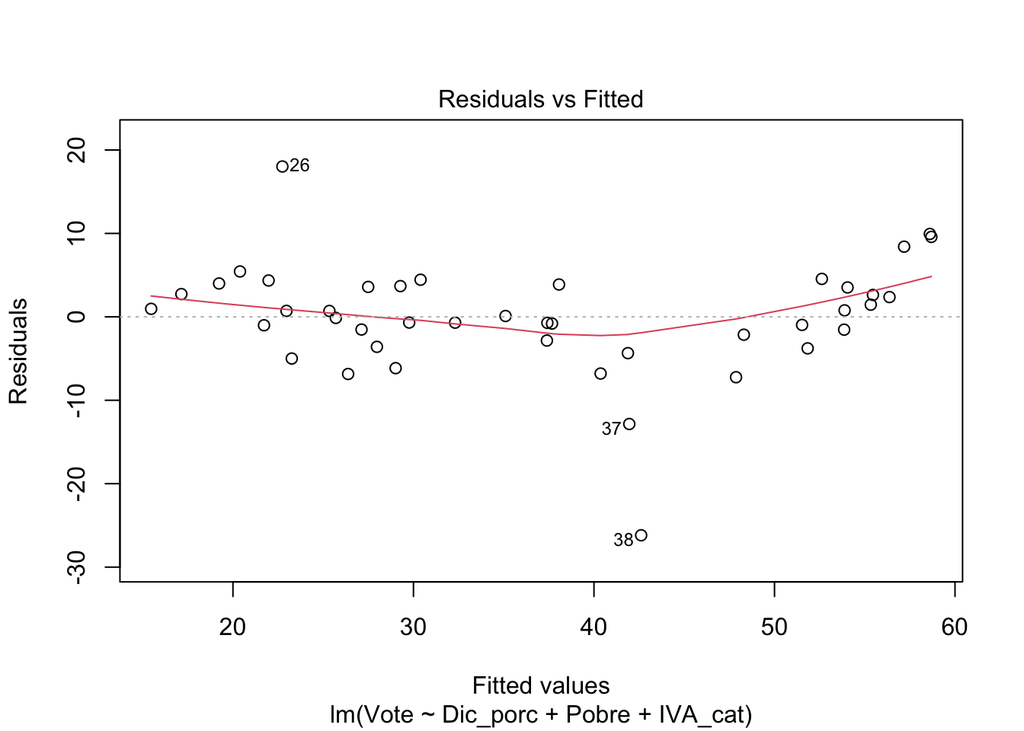

```r
plot(reg_ols1,1)
```

Buscamos una relación lineal entre variables. También podemos sacar el promedio de los residuos (la diferencia entre el valor esperado y el observado)

```r
mean(reg_ols1$residuals)
```

```
## [1] -4.145182e-18
```

#### Homocedasticidad:

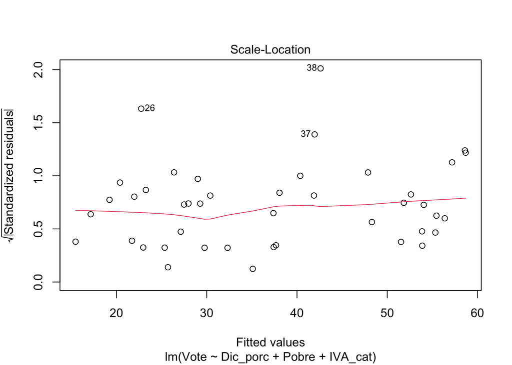

```r
plot(reg_ols1, 3)
```

Buscamos un p-valor mayor a .05. Esto nos muestra que nuestro modelo es homocedástico. La varianza de los errores es constante y no muestra un patrón. Esto es bueno!

```r
library(lmtest)
bptest(reg_ols1)
```

```
##
##  studentized Breusch-Pagan test
##
## data:  reg_ols1
## BP = 2.7841, df = 3, p-value = 0.4261
```

#### Normalidad de residuos:

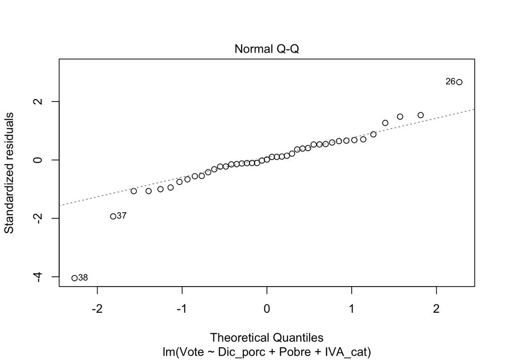

```r
plot(reg_ols1, 2)
```

```r
shapiro.test(reg_ols1$residuals)
```

```
##
##  Shapiro-Wilk normality test
##
## data:  reg_ols1$residuals
## W = 0.89807, p-value = 0.001094
```

#### No multicolinealidad:

Que no haya una correlación muy alta entre predictores. Idealmente menores a 3, aceptable hasta menor a 5.

```r
library(DescTools)
VIF(reg_ols1)
```

```
## Dic_porc    Pobre  IVA_cat
## 1.055620 1.839494 1.906874
```

#### Valores influyentes:

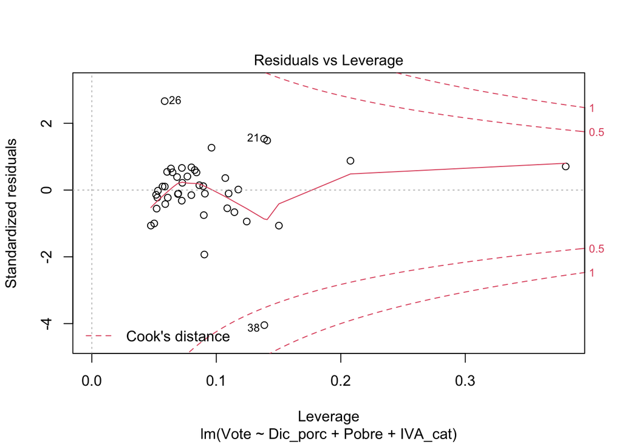

```r
plot(reg_ols1, 5)
```

```r
check = as.data.frame(influence.measures(reg_ols1)$is.inf)
check[check$cook.d & check$hat,]
```

```
## [1] dfb.1_   dfb.Dc_p dfb.Pobr dfb.IVA_ dffit    cov.r    cook.d   hat
## <0 rows> (or 0-length row.names)
```

Sin valores influyentes!

### B. Regresión Poisson (No lineal)

La regresión Poisson tiene sus supuestos:

- Variable de respuesta es un conteo por unidad de tiempo o espacio, que puede ser descrita por la distribución Poisson.
- Independencia: Las observaciones (filas) no deben tener relación entre sí.
- Media=Varianza: Por definición, la media de una variable que se distribuye como Poisson debe ser igual a su varianza.
- Linealidad: El logaritmo de la media de los datos, log(λ), debe ser una función lineal de los datos

Limpieza de la base de datos:

```r
data = import("Base - Nacional.sav")
```

```r
subdata = data[,c(2,4,5,7,8,15,16,29,82,57,58:63)]
colnames(subdata) = c("SEX","EDAD1","EDAD2","ESTUDIOS1","ESTUDIOS2","VIVIR_FUERA",
                      "FAM_FUERA","BARRIO","NOTICIAS","M_APARIENCIA","M_AMIGABLE",
                      "M_COQUETA","M_OPORTUNISTA","M_SEGURA","M_PROMISCUA","M_ATRACTIVA")
```

```r
subdata$VIVIR_FUERA = ifelse(subdata$VIVIR_FUERA == "Sí",1,0)
subdata$VIVIR_FUERA = factor(subdata$VIVIR_FUERA, levels = c(0:1), labels = c("No", "Sí"))
```

```r
subdata$M_APARIENCIA = ifelse(subdata$M_APARIENCIA == "Sí",1,0)
subdata$M_AMIGABLE = ifelse(subdata$M_AMIGABLE == "Sí, bastante",1,0)
subdata$M_COQUETA = ifelse(subdata$M_COQUETA == "Sí, bastante",1,0)
subdata$M_OPORTUNISTA = ifelse(subdata$M_OPORTUNISTA == "Sí, bastante",1,0)
subdata$M_SEGURA = ifelse(subdata$M_SEGURA == "Sí, bastante",1,0)
subdata$M_PROMISCUA = ifelse(subdata$M_PROMISCUA == "Sí, bastante",1,0)
subdata$M_ATRACTIVA = ifelse(subdata$M_ATRACTIVA == "Sí, bastante",1,0)
```

La variable dependiente:

```r
subdata$vd = subdata$M_APARIENCIA + subdata$M_OPORTUNISTA + subdata$M_PROMISCUA + subdata$M_COQUETA
```

Las independientes:

```r
#Genero:
subdata = subdata[subdata$SEX == "Hombre" |
                    subdata$SEX == "Mujer",]

subdata$SEX = ifelse(subdata$SEX == "Hombre",1,0)
subdata$SEX = factor(subdata$SEX, levels = c(0,1), labels = c("Mujer","Hombre"))
```

```r
#Comparte el barrio con personas venezolanas:
subdata$BARRIO[subdata$BARRIO == "No sabe / Prefiere no responder"] = NA

subdata$BARRIO = ifelse(subdata$BARRIO == "Sí",1,0)
subdata$BARRIO = factor(subdata$BARRIO, levels = c(0:1), labels = c("No", "Sí"))
```

```r
#Exposición a medios de comunicación:
subdata$NOTICIAS[subdata$NOTICIAS == "No sabe / Prefiere no responder"] = NA

subdata$NOTICIAS = ifelse(subdata$NOTICIAS == "Nunca",1,
                          ifelse(subdata$NOTICIAS == "Una vez al mes",2,
                          ifelse(subdata$NOTICIAS == "Una vez a la semana",3,
                          ifelse(subdata$NOTICIAS == "3 veces a la semana aprox.",4,
                          ifelse(subdata$NOTICIAS == "Todos los días",5,0)))))

subdata$NOTICIAS = factor(subdata$NOTICIAS, levels = c(1:5),
                          labels = c("Nunca","Una vez al mes","Una vez a la semana",
                                     "Tres veces a la semana","Todos los días"))
```

```r
library(fastDummies)
subdata=dummy_cols(subdata, select_columns = c("NOTICIAS"))
```

```r
colnames(subdata)[18] = "NUNCA"
colnames(subdata)[19] = "UNA_MES"
colnames(subdata)[20] = "UNA_SEMANA"
colnames(subdata)[21] = "TRES_SEMANA"
colnames(subdata)[22] = "TODOS_DIAS"
```

Le solicitan crear tres modelos para explicar las representaciones negativas sobre las mujeres migrantes:

- H1: Se explica por el hecho de que la persona encuestada compara el barrio con personas venezolanas (BARRIO)
- H2: Se explica por el hecho de compartir el barrio (BARRIO) con personas venezolanas y el género (SEX)
- H3: Se explica por esas dos variables y por ver todos los días noticias sobre personas migrantes en medios de comunicación (TODOS_DIAS)

```r
rp1=glm(vd ~ BARRIO, data = subdata, family = poisson(link = "log"))
rp2=glm(vd ~ BARRIO + SEX, data = subdata, family = poisson(link = "log"))
rp3=glm(vd ~ BARRIO + SEX + TODOS_DIAS, data = subdata, family = poisson(link = "log"))
```

```r
# displaying results
modelslmpoi=list('POISSON 1'=rp1,
                 'POISSON 2'=rp2,
                 'POISSON 3'=rp3)

modelsummary(modelslmpoi, title = "Regresiones Poisson",
             stars = TRUE,
             output = "kableExtra")
```

Regresiones Poisson

|  | POISSON 1 | POISSON 2 | POISSON 3 |
| --- | --- | --- | --- |
| (Intercept) | 0.662*** | 0.697*** | 0.642*** |
|  | (0.033) | (0.038) | (0.040) |
| BARRIOSí | 0.155*** | 0.155*** | 0.105* |
|  | (0.042) | (0.042) | (0.043) |
| SEXHombre |  | −0.075+ | −0.090* |
|  |  | (0.042) | (0.042) |
| TODOS_DIAS |  |  | 0.355*** |
|  |  |  | (0.045) |
| Num.Obs. | 1084 | 1084 | 1047 |
| AIC | 3871.7 | 3870.5 | 3674.4 |
| BIC | 3881.6 | 3885.4 | 3694.2 |
| Log.Lik. | −1933.829 | −1932.227 | −1833.196 |
| F | 13.421 | 8.310 | 26.554 |
| RMSE | 1.45 | 1.45 | 1.40 |

+ p < 0.1, * p < 0.05, ** p < 0.01, *** p < 0.001

¿Qué resultados tenemos, por ejemplo, del segundo modelo?

- El hecho de compartir barrio con personas venezolanas aumenta la probabilidad de adherirse a representaciones negativas de las mujeres migrantes
- El hecho de ser hombre no tiene impactos estadísticamente significativos en la probabilidad.

Pero debemos exponenciar los coeficientes:

```r
modelsummary(modelslmpoi, title = "Regresiones Poisson",
             stars = TRUE,
             statistic = 'conf.int',
             exponentiate = T, # exponenciar!!!!!
             output = "kableExtra")
```

Regresiones Poisson

|  | POISSON 1 | POISSON 2 | POISSON 3 |
| --- | --- | --- | --- |
| (Intercept) | 1.938*** | 2.007*** | 1.901*** |
|  | [1.817, 2.065] | [1.862, 2.159] | [1.756, 2.055] |
| BARRIOSí | 1.168*** | 1.168*** | 1.111* |
|  | [1.075, 1.270] | [1.075, 1.269] | [1.021, 1.210] |
| SEXHombre |  | 0.928+ | 0.914* |
|  |  | [0.854, 1.007] | [0.841, 0.993] |
| TODOS_DIAS |  |  | 1.426*** |
|  |  |  | [1.305, 1.557] |
| Num.Obs. | 1084 | 1084 | 1047 |
| AIC | 3871.7 | 3870.5 | 3674.4 |
| BIC | 3881.6 | 3885.4 | 3694.2 |
| Log.Lik. | −1933.829 | −1932.227 | −1833.196 |
| F | 13.421 | 8.310 | 26.554 |
| RMSE | 1.45 | 1.45 | 1.40 |

+ p < 0.1, * p < 0.05, ** p < 0.01, *** p < 0.001

De forma más sencilla, si quisiéramos el impacto del hecho de compartir barrio con personas venezolanas sobre la probabilidad en el modelo 2. Hacemos lo siguiente:

```r
exp(coef(rp2)[['BARRIOSí']]) #Personas venezolanas en el barrio
```

```
## [1] 1.167723
```

```r
exp_rp2 = 1-1.167723
exp_rp2 = exp_rp2*-1
exp_rp2
```

```
## [1] 0.167723
```

```r
100*exp_rp2
```

```
## [1] 16.7723
```

El hecho de compartir el barrio con personas migrantes aumenta la probabilidad de adherirse a representaciones negativas de mujeres migrantes en 17%

Y el impacto de ver noticias sobre personas migrantes en medios de comunicación todos los días:

```r
exp(coef(rp3)[['TODOS_DIAS']])
```

```
## [1] 1.425909
```

El hecho de ver noticias sobre personas migrantes en medios de comunicación todos los días aumenta la probabilidad de adherirse a representaciones negativas de mujeres migrantes en 43%

```r
exp_rp3 = 1-1.425909
exp_rp3 = exp_rp3*-1
exp_rp3*100
```

```
## [1] 42.5909
```

Uno de los supuestos en la Regresión Poisson es que la media y la varianza sean iguales. Veamos:

```r
library(magrittr)
overdispersion=AER::dispersiontest(rp3,alternative='greater')$ p.value<0.05
underdispersion=AER::dispersiontest(rp3,alternative='less')$ p.value<0.05
# tabla
testResult=as.data.frame(rbind(overdispersion,underdispersion))
names(testResult)='Es probable?'
testResult%>%kable(caption = "Test de Equidispersión")%>%kableExtra::kable_styling()
```

Test de Equidispersión

|  | Es probable? |
| --- | --- |
| overdispersion | FALSE |
| underdispersion | TRUE |

La prueba nos muestra que es altamente probable que tengamos subdispersión. Corresponde un modelo quasipoisson:

```r
rqp = glm(vd ~ BARRIO + SEX + TODOS_DIAS, data = subdata,
          family = quasipoisson(link = "log"))

modelsPQP=list('POISSON'=rp3,'QUASIPOISSON'=rqp)

modelsummary(modelsPQP,
             title = "Regresiones Poisson y QuasiPoisson",
             stars = TRUE,
             output = "kableExtra")
```

Regresiones Poisson y QuasiPoisson

|  | POISSON | QUASIPOISSON |
| --- | --- | --- |
| (Intercept) | 0.642*** | 0.642*** |
|  | (0.040) | (0.039) |
| BARRIOSí | 0.105* | 0.105* |
|  | (0.043) | (0.042) |
| SEXHombre | −0.090* | −0.090* |
|  | (0.042) | (0.041) |
| TODOS_DIAS | 0.355*** | 0.355*** |
|  | (0.045) | (0.044) |
| Num.Obs. | 1047 | 1047 |
| AIC | 3674.4 |  |
| BIC | 3694.2 |  |
| Log.Lik. | −1833.196 |  |
| F | 26.554 | 28.284 |
| RMSE | 1.40 | 1.40 |

+ p < 0.1, * p < 0.05, ** p < 0.01, *** p < 0.001

Observamos una ligera reducción de errores típicos:

```r
library(arm)
cbind(se_Poi=se.coef(rp3),se_QuasiPoi=se.coef(rqp))
```

```
##                 se_Poi se_QuasiPoi
## (Intercept) 0.04007593  0.03883061
## BARRIOSí    0.04329804  0.04195260
## SEXHombre   0.04236038  0.04104407
## TODOS_DIAS  0.04502439  0.04362531
```

Comparemos ambos modelos:

```r
anova(rp3,rqp, test = "Chisq") %>%
kable(caption = "Tabla ANOVA para comparar modelos")%>%kableExtra::kable_styling(full_width = FALSE)
```

Tabla ANOVA para comparar modelos

| Resid. Df | Resid. Dev | Df | Deviance | Pr(>Chi) |
| --- | --- | --- | --- | --- |
| 1043 | 1298.905 | NA | NA | NA |
| 1043 | 1298.905 | 0 | 0 | NA |

En realidad no hay una mejora sustancial en el modelo. Sin embargo, la binomial negativa (la alternativa que nos queda) no es la más apropiada en un caso de subdispersión.

### C. Regresión Logística

**Ideas clave**

- La probabilidad: Es una medida que señala que tan posible es que ocurra un fenómeno o evento. Oscila entre 0 y 1. Cuanto más cerca de 0 menos probabilidad, y cuanto más cerca del 1 indica más probabilidad. Ejemplo: la probabilidad de ganar en un partido de futbol.
- Odds: Es la probabilidad de que suceda un evento dividido por la probabilidad de que no suceda. Oscilan entre 0 e infinito y se pueden calcular para la ocurrencia del evento como para la no ocurrencia del evento. Ejemplo: la probabilidad de ganar una apuesta en un partido de futbol es 1.5 veces más probable que perder
- ODDs Ratio: Es la razón entre dos odds. Permite comparar los odds de un evento en dos grupos Va de 0 a infinito. Los modelos de regresión logística están basados en probabilidades entre dos variables. Por esta razón, es útil conocer los ODDs ratio. Ejemplo: Ganar en una apuesta de un partido de futbol es 5 veces más probable que el ganar en una apuesta de voley
- La regresión logística modela el comportamiento de la probabilidad del evento de interés. Es un tipo de análisis de regresión utilizado para predecir el resultado de una variable categórica (dependiente) en función de las variables predictoras (independientes). Es útil para modelar la probabilidad de que ocurra un evento en función del efecto de un conjunto de variables.
- La idea es que la regresión logística aproxime la probabilidad de obtener “0” (no ocurre cierto suceso) o “1” (ocurre el suceso) con el valor de la variable explicativa x.

Modelemos la probabilidad de que una persona considere que las mujeres venezolanas consiguen trabajo por su apariencia:

```r
table(subdata$M_APARIENCIA)
```

```
##
##   0   1
## 424 684
```

¿Está relacionado ello con el género de la persona encuestada?

```r
dep=subdata$M_APARIENCIA # a la fila
ind=subdata$SEX # a la columna

NarrsexTable=table(dep,ind,dnn = c('Narrative','Gender'))

### suma por fila y columna
addmargins(NarrsexTable)%>%
    kable(caption = "Tabla de Contingencia: 'Género' y 'Creer la narrativa'")%>%
    kableExtra::kable_styling(full_width = F)
```

Tabla de Contingencia: ‘Género’ y ‘Creer la narrativa’

|  | Mujer | Hombre | Sum |
| --- | --- | --- | --- |
| 0 | 228 | 196 | 424 |
| 1 | 359 | 325 | 684 |
| Sum | 587 | 521 | 1108 |

La probabilidad que una mujer crea la narrativa

```r
ProbMujNarr=NarrsexTable[2,1]/sum(NarrsexTable[,1])
MASS::fractions(ProbMujNarr)
```

```
## [1] 359/587
```

```r
ProbMujNarr
```

```
## [1] 0.6115843
```

Representemos el ODDS de creerlo con respecto a quienes no lo creen

```r
OddsMujNarr=NarrsexTable[2,1]/NarrsexTable[1,1]
MASS::fractions(OddsMujNarr)
```

```
## [1] 359/228
```

```r
OddsMujNarr
```

```
## [1] 1.574561
```

O lo que es lo mismo:

```r
ProbMujNarr/(1-ProbMujNarr)
```

```
## [1] 1.574561
```

Ahora saquemos el ODDS Ratio (en función al hombre)

```r
ProbHombNarr=NarrsexTable[2,2]/sum(NarrsexTable[,2])
OddsHombNarr = ProbHombNarr/(1-ProbHombNarr)
```

ODDS ratio:

```r
(OR_MujHom=OddsMujNarr/OddsHombNarr)
```

```
## [1] 0.9495816
```

Un factor de .05. Prácticamente no hay diferencias.

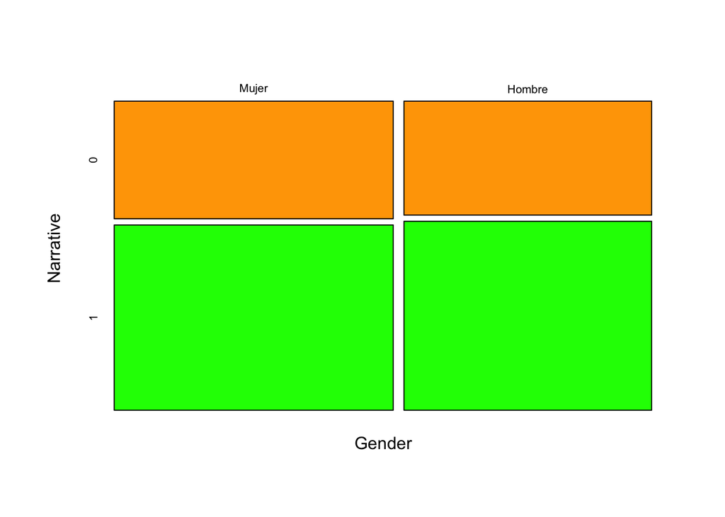

```r
mosaicplot( t(NarrsexTable),col = c("orange", "green"),main = "")
```

Veamos si hay diferencias estadísticamente significativas:

```r
set.seed(2023)

### first hypothesis
h1=formula(M_APARIENCIA~SEX)

#regression
rlog1=glm(h1, data=subdata,family = binomial)
modelrl=list('Trabajo por su apariencia'=rlog1)

#f <- function(x) format(x, digits = 4, scientific = FALSE)
modelsummary(modelrl,
             title = "Regresión Logística",
             stars = TRUE,
             output = "kableExtra")
```

Regresión Logística

|  | Trabajo por su apariencia |
| --- | --- |
| (Intercept) | 0.454*** |
|  | (0.085) |
| SEXHombre | 0.052 |
|  | (0.124) |
| Num.Obs. | 1108 |
| AIC | 1478.3 |
| BIC | 1488.3 |
| Log.Lik. | −737.128 |
| F | 0.174 |
| RMSE | 0.49 |

+ p < 0.1, * p < 0.05, ** p < 0.01, *** p < 0.001

Y lo comprobamos en la medida que no hay impactos estadísticamente significativos.

Probemos estas hipotesis. La adhesión a esta narrativa se explica por:

- H1: El género (SEX) y la edad (EDAD1)
- H2: El género (SEX), la edad (EDAD1) y haber vivido fuera del país (VIVIR_FUERA)
- H3: El género (SEX), la edad (EDAD1), haber vivido fuera del país (VIVIR_FUERA) y la exposición a medios de comunicación diaria a medios de comunicación (TODOS_DIAS)

```r
h1=formula(M_APARIENCIA ~ SEX + EDAD1)
h2=formula(M_APARIENCIA ~ SEX + EDAD1 + VIVIR_FUERA)
h3=formula(M_APARIENCIA ~ SEX + EDAD1 + VIVIR_FUERA + TODOS_DIAS)
```

```r
rlog1=glm(h1, data=subdata,family = binomial)
rlog2=glm(h2, data=subdata,family = binomial)
rlog3=glm(h3, data=subdata,family = binomial)
```

```r
summary(rlog1)
```

```
##
## Call:
## glm(formula = h1, family = binomial, data = subdata)
##
## Deviance Residuals:
##     Min       1Q   Median       3Q      Max
## -1.4609  -1.3720   0.9585   0.9900   1.0282
##
## Coefficients:
##             Estimate Std. Error z value Pr(>|z|)
## (Intercept) 0.290076   0.185148   1.567    0.117
## SEXHombre   0.061031   0.124305   0.491    0.623
## EDAD1       0.003979   0.004008   0.993    0.321
##
## (Dispersion parameter for binomial family taken to be 1)
##
##     Null deviance: 1474.4  on 1107  degrees of freedom
## Residual deviance: 1473.3  on 1105  degrees of freedom
## AIC: 1479.3
##
## Number of Fisher Scoring iterations: 4
```

```r
summary(rlog2)
```

```
##
## Call:
## glm(formula = h2, family = binomial, data = subdata)
##
## Deviance Residuals:
##     Min       1Q   Median       3Q      Max
## -1.4724  -1.3718   0.9550   0.9883   1.0693
##
## Coefficients:
##                Estimate Std. Error z value Pr(>|z|)
## (Intercept)    0.298451   0.185530   1.609    0.108
## SEXHombre      0.069020   0.124808   0.553    0.580
## EDAD1          0.004102   0.004013   1.022    0.307
## VIVIR_FUERASí -0.141314   0.189880  -0.744    0.457
##
## (Dispersion parameter for binomial family taken to be 1)
##
##     Null deviance: 1474.4  on 1107  degrees of freedom
## Residual deviance: 1472.7  on 1104  degrees of freedom
## AIC: 1480.7
##
## Number of Fisher Scoring iterations: 4
```

```r
summary(rlog3)
```

```
##
## Call:
## glm(formula = h3, family = binomial, data = subdata)
##
## Deviance Residuals:
##     Min       1Q   Median       3Q      Max
## -1.7523  -1.3132   0.7861   1.0274   1.1294
##
## Coefficients:
##                Estimate Std. Error z value Pr(>|z|)
## (Intercept)    0.149906   0.193329   0.775    0.438
## SEXHombre      0.009019   0.128717   0.070    0.944
## EDAD1          0.005531   0.004197   1.318    0.188
## VIVIR_FUERASí -0.172022   0.195462  -0.880    0.379
## TODOS_DIAS     0.700258   0.156588   4.472 7.75e-06 ***
## ---
## Signif. codes:  0 '***' 0.001 '**' 0.01 '*' 0.05 '.' 0.1 ' ' 1
##
## (Dispersion parameter for binomial family taken to be 1)
##
##     Null deviance: 1412.5  on 1068  degrees of freedom
## Residual deviance: 1387.8  on 1064  degrees of freedom
##   (39 observations deleted due to missingness)
## AIC: 1397.8
##
## Number of Fisher Scoring iterations: 4
```

```r
modelsrl=list('Adhesión (I)'=rlog1,
             'Adhesión (II)'=rlog2,
             'Adhesión (III)'=rlog3)

# formato creado para modelsummary
formatoNumero = function(x) format(x, digits = 4, scientific = FALSE)
modelsummary(modelsrl,
             fmt=formatoNumero, # usa función que creé antes
             exponentiate = T, # coeficientes sin logaritmo
             statistic = 'conf.int', # mostrar ICs
             title = "Regresión Logísticas (Coeficientes Exponenciados)",
             stars = TRUE,
             output = "kableExtra")
```

Regresión Logísticas (Coeficientes Exponenciados)

|  | Adhesión (I) | Adhesión (II) | Adhesión (III) |
| --- | --- | --- | --- |
| (Intercept) | 1.337 | 1.3478 | 1.162 |
|  | [0.9300, 1.923] | [0.9371, 1.940] | [0.7951, 1.697] |
| SEXHombre | 1.063 | 1.0715 | 1.009 |
|  | [0.8332, 1.357] | [0.8391, 1.369] | [0.7841, 1.299] |
| EDAD1 | 1.004 | 1.0041 | 1.006 |
|  | [0.9962, 1.012] | [0.9963, 1.012] | [0.9973, 1.014] |
| VIVIR_FUERASí |  | 0.8682 | 0.842 |
|  |  | [0.5998, 1.264] | [0.5753, 1.240] |
| TODOS_DIAS |  |  | 2.014*** |
|  |  |  | [1.4882, 2.751] |
| Num.Obs. | 1108 | 1108 | 1069 |
| AIC | 1479.3 | 1480.7 | 1397.8 |
| BIC | 1494.3 | 1500.8 | 1422.7 |
| Log.Lik. | −736.633 | −736.358 | −693.917 |
| F | 0.580 | 0.570 | 5.806 |
| RMSE | 0.49 | 0.49 | 0.48 |

+ p < 0.1, * p < 0.05, ** p < 0.01, *** p < 0.001

De este modelo, el principal hallazgo es que solo el modelo 3 presenta una variable estadísticamente significativa: ver noticias sobre personas migrantes todos los días en medios de comunicación.

Esto, sin embargo, es dificil de interpretar. Calculemos los efectos marginales:

```r
library(margins)
marginalsData=summary(margins(rlog3))
marginalsData%>% kable(caption = "Efectos Marginales Promedio (AME)- Modelo III") %>%kableExtra::kable_styling(full_width = T)
```

Efectos Marginales Promedio (AME)- Modelo III

| factor | AME | SE | z | p | lower | upper |
| --- | --- | --- | --- | --- | --- | --- |
| EDAD1 | 0.0012650 | 0.0009570 | 1.3217947 | 0.1862365 | -0.0006107 | 0.0031408 |
| SEXHombre | 0.0020628 | 0.0294359 | 0.0700778 | 0.9441318 | -0.0556304 | 0.0597560 |
| TODOS_DIAS | 0.1601665 | 0.0346221 | 4.6261351 | 0.0000037 | 0.0923084 | 0.2280245 |
| VIVIR_FUERASí | -0.0399361 | 0.0459538 | -0.8690483 | 0.3848207 | -0.1300039 | 0.0501317 |

Ahora sabemos que el hecho de ver todos los días estas noticias aumenta la probabilidad de adherirse a la narrativa en .16 (o 16%).

### D. Regresión Cox

El objetivo de la regresión Cox es evaluar los impactos de diferentes variables sobre la “sobrevivencia”. Es decir, nos ayuda a saber si ciertos factores influecian la tasa de ocurrencia de un evento en específico en un lapso de tiempo.

```r
library(survival)
library(survminer)
```

Vamos a trabajar con una base de datos de personas con cancer al pulmón:

```r
head(lung)
```

```
##   inst time status age sex ph.ecog ph.karno pat.karno meal.cal wt.loss
## 1    3  306      2  74   1       1       90       100     1175      NA
## 2    3  455      2  68   1       0       90        90     1225      15
## 3    3 1010      1  56   1       0       90        90       NA      15
## 4    5  210      2  57   1       1       90        60     1150      11
## 5    1  883      2  60   1       0      100        90       NA       0
## 6   12 1022      1  74   1       1       50        80      513       0
```

Estas son las variables:

inst: Institution code time: Survival time in days status: censoring status 1=censored, 2=dead age: Age in years sex: Male=1 Female=2 ph.ecog: ECOG performance score (0=good 5=dead) ph.karno: Karnofsky performance score (bad=0-good=100) rated by physician pat.karno: Karnofsky performance score as rated by patient meal.cal: Calories consumed at meals wt.loss: Weight loss in last six months

Vamos a ver algunos descriptivos del tiempo de sobrevivencia:

```r
summary(lung$time)
```

```
##    Min. 1st Qu.  Median    Mean 3rd Qu.    Max.
##     5.0   166.8   255.5   305.2   396.5  1022.0
```

Ahora de la ocurrencia del evento:

```r
#Recodificamos para que 0 sea la ocurrencia:
lung$status1 = ifelse(lung$status == 2,1,0)
table(lung$status1)
```

```
##
##   0   1
##  63 165
```

Empezamos con el análisis:

```r
lung$survival=with(lung,Surv(time = time,
                             event =  status1))
```

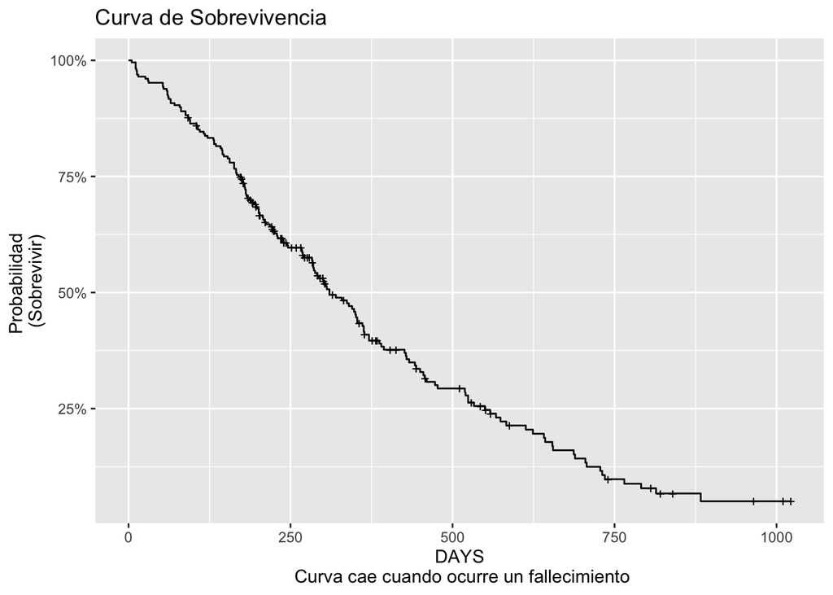

```r
library(ggplot2)
library(ggfortify)

KM.generico = survfit(survival ~ 1, data = lung)

ejeX='DAYS\n Curva cae cuando ocurre un fallecimiento'
ejeY='Probabilidad \n(Sobrevivir)'
titulo="Curva de Sobrevivencia"
autoplot(KM.generico,xlab=ejeX,ylab=ejeY, main = titulo,conf.int = F)
```

Ahora probemos una hipótesis: los hombres tienen una menor probabilidad de sobrevivir.

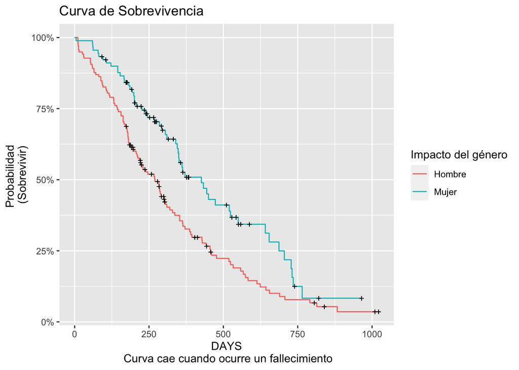

```r
KM_H1=formula(survival ~ sex)

KM.sex = survfit(KM_H1, data = lung)

###
ejeX='DAYS\n Curva cae cuando ocurre un fallecimiento'
ejeY='Probabilidad \n(Sobrevivir)'
titulo="Curva de Sobrevivencia"

autoplot(KM.sex,xlab=ejeX,ylab=ejeY,
         main = titulo,conf.int = F)  +
        labs(colour = "Impacto del género") +
         scale_color_discrete(labels = c("Hombre", "Mujer"))
```

Efectivamente, parece que la mejor no pinta tan bien para los hombres. Veamos los intervalos de confianza:

```r
LogRank=survdiff(KM_H1, data = lung)
LogRank$pvalue
```

[output not shown]

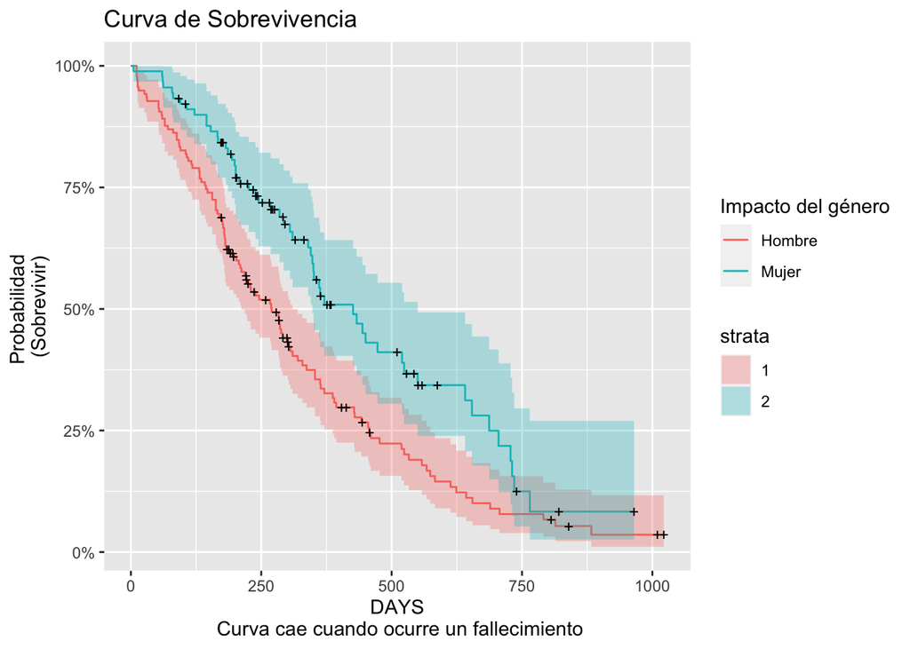

```r
autoplot(KM.sex,xlab=ejeX,ylab=ejeY,
         main = titulo,conf.int = T)+
        labs(colour = "Impacto del género") +
         scale_color_discrete(labels = c("Hombre", "Mujer"))
```

Probemos ahora otra hipótesis: más joven es la persona, sus probabilidad de sobrevivir serán mayores. Para ver cómo juegan ambas variables a la vez, hay que evaluarlo con una regresión:

```r
COX_H1= formula(survival~factor(sex)+age)
rcox1 <- coxph(COX_H1,data=lung)
summary(rcox1)
```

```
## Call:
## coxph(formula = COX_H1, data = lung)
##
##   n= 228, number of events= 165
##
##                   coef exp(coef)  se(coef)      z Pr(>|z|)
## factor(sex)2 -0.513219  0.598566  0.167458 -3.065  0.00218 **
## age           0.017045  1.017191  0.009223  1.848  0.06459 .
## ---
## Signif. codes:  0 '***' 0.001 '**' 0.01 '*' 0.05 '.' 0.1 ' ' 1
##
##              exp(coef) exp(-coef) lower .95 upper .95
## factor(sex)2    0.5986     1.6707    0.4311    0.8311
## age             1.0172     0.9831    0.9990    1.0357
##
## Concordance= 0.603  (se = 0.025 )
## Likelihood ratio test= 14.12  on 2 df,   p=9e-04
## Wald test            = 13.47  on 2 df,   p=0.001
## Score (logrank) test = 13.72  on 2 df,   p=0.001
```

Vemos que el género tiene un impacto negativo sobre la probabilidad de fallecimiento. Es decir, el ser mujer (2) disminuye la probabilidad de ocurrencia del evento. Esto es estadísticamente significativo, mientras que la edad no muestra impactos. Pero, en tanto esta es una combinación lineal, no se pueden interpretar directamente:

```r
(sex=abs(1-exp(coef(rcox1)[1])))
```

```
## factor(sex)2
##     0.401434
```

Esto ya se puede interpretar: ser mujer está asociado con un mejor pronóstico, reduciendo las probabilidades de ocurrencia del evento en 40%.